# Spectra Story

Author

Adam Kemberling

Published

October 1, 2024

## Storycrafting - Northeast Shelf Spectra

I think we need to step back a bit and find the main story again–which is about how size structure of the NES fish community has changed over time, whether that varies by region, and what covariates are associated with those changes.

The Aug draft you developed really focused on comparing regression models to consider drivers based on the fish community size spectrum as viewed from the perspective of the Wigley species set vs. the full species set.

However, I didn’t see figures of those spectra in that draft (maybe there are somewhere else and I’ve lost track). The recent slide deck really focuses on seasonal differences in the size spectra and influence of temperature.

## Starting from Square Uno

I’d like for us to start by rebuilding the story of how the size structure has changed over time and regional differences.

As such, I would like for us to look at plots of the size spectrum slope for (1) the all-species length spectrum and (2) the Wigley species biomass spectrum from annual, seasonal and regional perspectives.

I am thinking this would be two panel plots (all-spp length, Wigley-spp biomass) with 5 subpanels each (NES, GOM, GB, SNE, MAB) that are set up to show lines by seasonal and annual time steps, much like the plot on the right of slide 7 in your most recent slide deck…except with NES added and an annual line added. Keeping the significant trend lines in is helpful. This is the first step, so when you have that ready, please share it with the group.

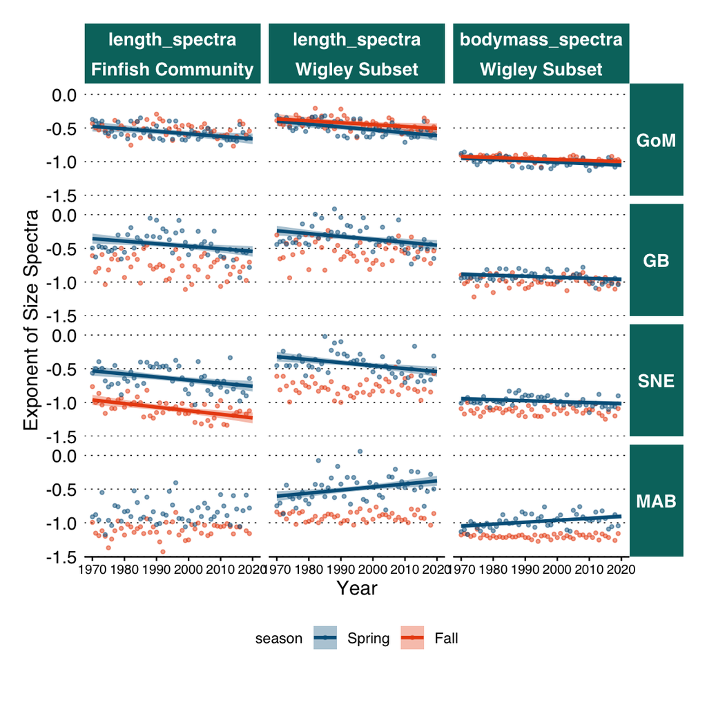

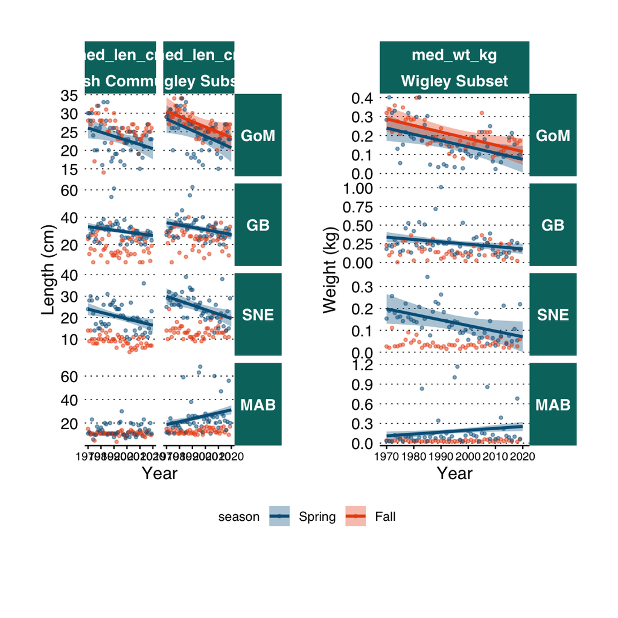

Couple things have started to catch my eye the more I’ve thought about volatility in these numbers. There seem to be two situations happening on occassion. The first is more common in GOM+GB, and that is a 5-10cm drop in median length. This sudden drop in size I am imagining is likely due to surges in new recruits.

The other patttern which is more common in MAB but looks like it happens a handful of times in GB is the reverse situation, where median size surges upward in isolated years. For these situations I think we likely could trace these down to exceptionally high catches of larger species like elasmobranchs.

## Summary of Trends

Let’s start with these pieces, and we can then discuss doing something with the extremes of the size distribution–changes in small vs. large individuals, where we pre-define size bins as you’ve done in slides 7 and 8, or perhaps using an approach similar to Lora’s approach of defining the upper/lower percentiles of size.

Hope this sounds good as some first steps towards shaping out the results section. And I hope once we see these, we can iterate forward to next steps pretty quickly.

### Spiny Dogfish Sensitivity

How much can one species shift the spectra

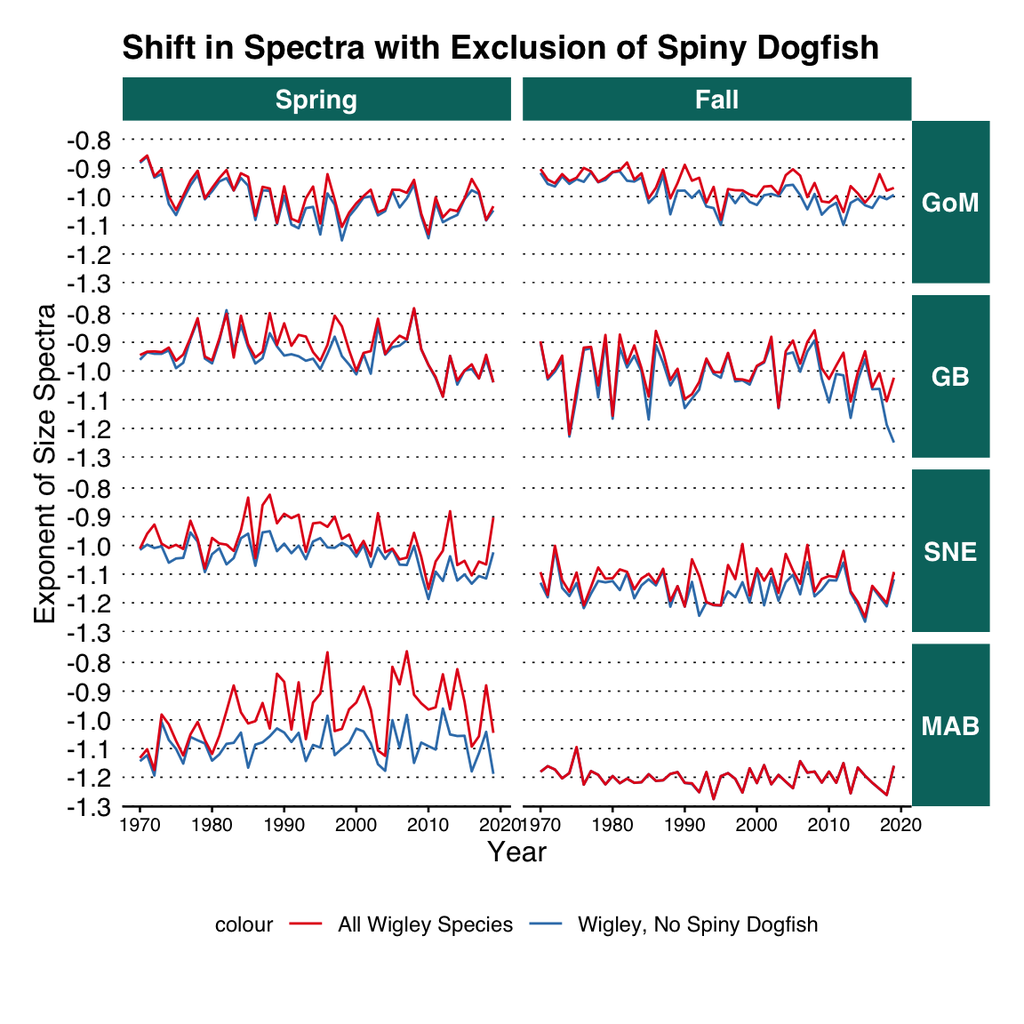

# Distractions

### Initial Thoughts I’d like to Discuss

Our hypotheses both relate primarily to abundance of non-age0 fishes. It might make sense to move the minimum size up to something larger. This will accomplish two things: 1) lower any noise in median size or spectra slope that results from large recruit cohorts & 2) help ensure that the size range we’re estimating spectra for are fully selected by the gear.

Currently a 1g minimum size is likely lower than the mesh size selectivity.

The following plot shows what the distriution looks like for all data (years, seasons, areas) over the range of sizes we are allowing to contribute to the estimation of seasonal spectra. I’ve highlighted where a minimum body size of 1g sits on this curve to mark where it sits.

## Is it even Pareto?

It is quite a pain to determine whether the data follow a pareto distribution in the first place. I’m unsure if the lines in the plots below faithfully follow how they are estimated and how to score goodness of fit for a probability density function.

After doing some attempts to plot the impacts of moving it around, I am less convinced that its helping things and it may even be harming the situation.

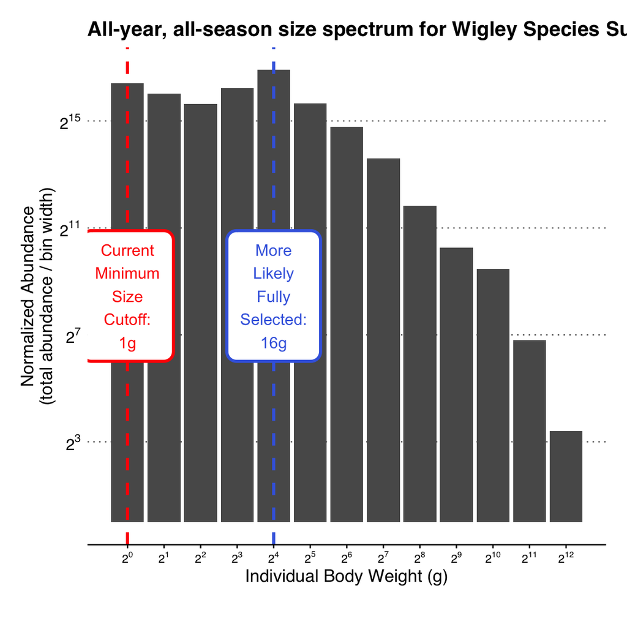

I picked 16g here basically eyeballing things, but my point is mostly that I think there is a need and an advantage to shifting the minimum size. There is a similar lack of tuning for minimum length as well.

We could probably be more scientific and look at the mesh size used, but I think precision there is less important that being closer than we are now.

For maximum size we presently take the maximum individual size in that area-year-season unit. While this also affects the distribution shape I am less concerned with this for now.

## What if we shift it?

I’m just going to go ahead and do it and see

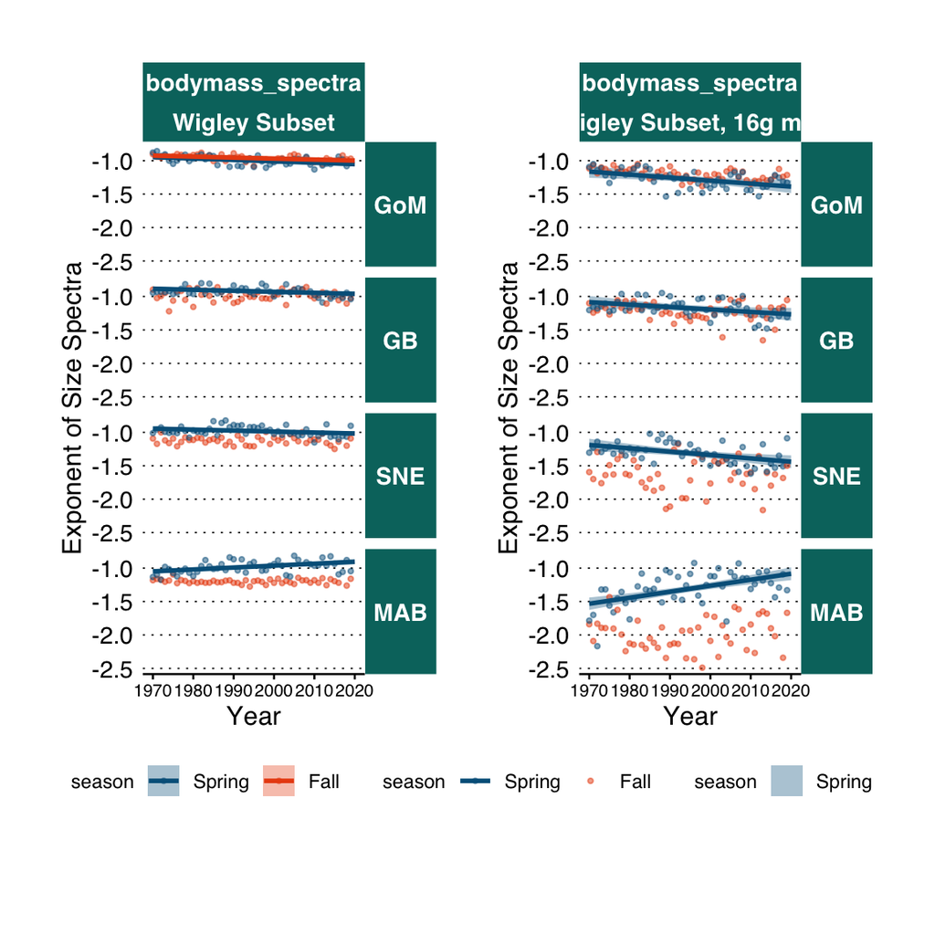

### Sensitivity to minimum size

**1g cutoff**

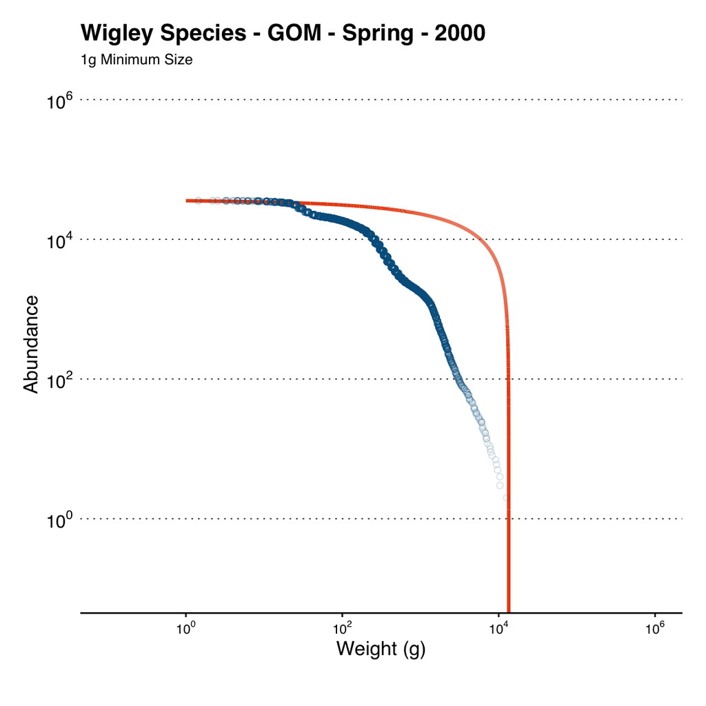

**16g Cutoff**

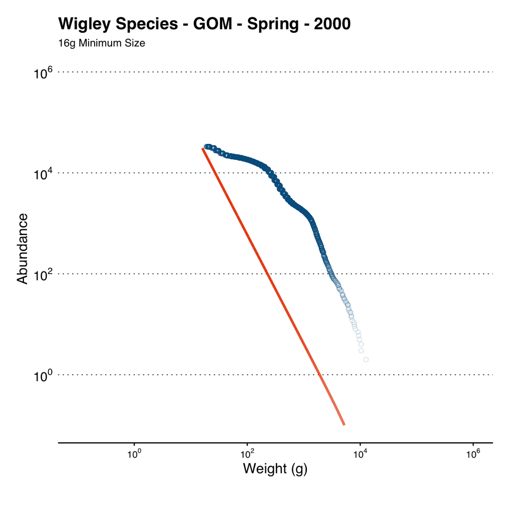

### Sensitivity to max size

**1g Cutoff**

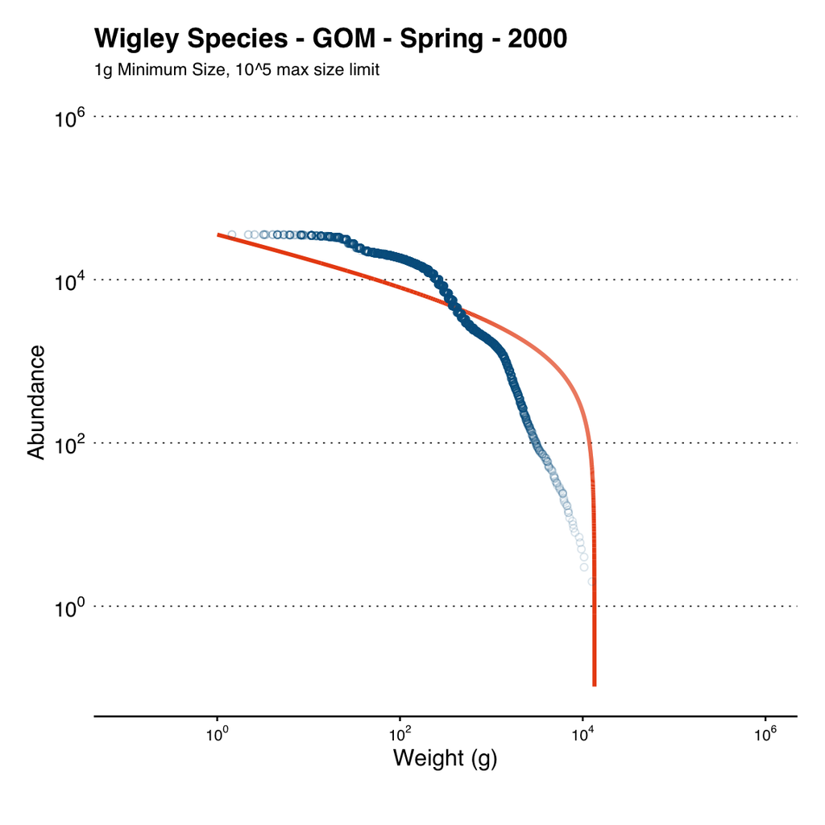

**16g Cutoff**

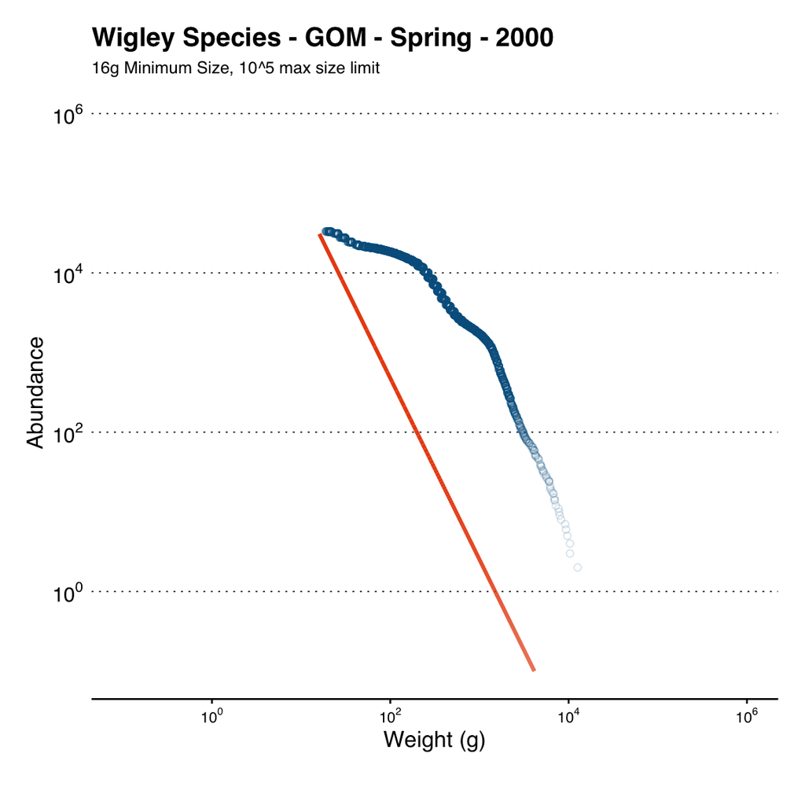